# Introduction to Bayesian Statistics

Rebecca C. Steorts  
17 January 2017

### Agenda

- Motivations
- Traditional inference
- Bayesian inference
- Bernoulli, Beta, and Binomial distributions
- Posterior of Beta-Binomial
- Example with 2012 election data
- Marginal likelihood
- Posterior Prediction

### Motivations for Bayesian statistics

- Understanding social networks
- Predicting elections
- Estimating the size of a population
- Estimating hard to reach populations (domains)

### Traditional inference

You are given **data** \( X \) and there is an **unknown parameter** you wish to estimate **\( \theta \)**

How would you estimate \( \theta \)?

- Find an unbiased estimator of \( \theta \).
- Find the maximum likelihood estimate (MLE) of \( \theta \) by looking at the likelihood of the data.
- If you cannot remember the definition of an unbiased estimator or the MLE, review these before our next class.

### Bayesian inference

Bayesian methods trace its origin to the 18th century and English Reverend Thomas Bayes, who along with Pierre-Simon Laplace discovered what we now call **Bayes' Theorem**

- \( p(x \mid \theta) \) likelihood
- \( p(\theta) \) prior
- \( p(\theta \mid x) \) posterior
- \( p(x) \) marginal distribution

\[ p(\theta|x) = \frac{p(\theta,x)}{p(x)} = \frac{p(x|\theta)p(\theta)}{p(x)} \propto p(x|\theta)p(\theta) \]

### Bernoulli distribution

The Bernoulli distribution is very common due to binary outcomes.

- Consider flipping a coin (heads or tails).
- We can represent this a binary random variable where the probability of heads is \( \theta \) and the probability of tails is \( 1-\theta. \)

The write the random variable as \( X \sim \Bernoulli(\theta) \I(0 < \theta < 1) \)

It follows that the likelihood is \[ p(x \mid \theta) = \theta^x (1-\theta)^{(1-x)}\I(0 < \theta < 1). \]

- Exercise: what is the mean and the variance of \( X \)?

### Binomial distribution

- Suppose that \( X_1,\ldots,X_n \stackrel{iid}{\sim} \Bernoulli(\theta). \) Then for \( x_1,\ldots,x_n \in \{0,1\} \) what is the likelihood?

### Likelihood

\[ \begin{aligned} p(x_{1:n}|\theta) &= \Pr(X_1 = x_1,\dotsc,X_n = x_n\mid\theta) \notag\\ & =\prod_{i = 1}^n \Pr(X_i = x_i\mid\theta) \notag\\ & = \prod_{i = 1}^n p(x_i|\theta) \notag\\ & =\prod_{i = 1}^n \theta^{x_i}(1-\theta)^{1-x_i} \notag\\ & =\theta^{\sum x_i}(1-\theta)^{n-\sum x_i}. \label{equation:likelihood} \end{aligned} \]

### Beta distribution

Given \( a,b>0 \), we write \( \theta \sim \Beta(a,b) \) to mean that \( \theta \) has pdf

\[ p(\theta) =\Beta(\theta|a,b) =\frac{1}{B(a,b)}\theta^{a-1}(1-\theta)^{b-1}\I(0<\theta<1), \]

i.e., \( p(\theta)\propto \theta^{a-1}(1-\theta)^{b-1} \) on the interval from \( 0 \) to \( 1 \).

- Here, \[ B(a,b) = \frac{\Gamma(\alpha)\Gamma(\beta)}{\Gamma(\alpha+\beta)} \].
- The mean is \( E(\theta) =\int \theta\,p(\theta)d\theta = a/(a+b) \).

### Notation

- \( \propto \): means “proportional to”
- \( x_{1:n} \) denotes \( x_1,\ldots,x_n \)

### Posterior of Binomial-Beta

Lets derive the posterior of \( \; \theta \mid x_{1:n} \)

\[ \begin{aligned} &p(\theta|x_{1:n}) \\ &\propto p(x_{1:n}|\theta) p(\theta)\notag\\ & =\theta^{\sum x_i}(1-\theta)^{n-\sum x_i}\frac{1}{B(a,b)}\theta^{a-1}(1-\theta)^{b-1}I(0<\theta<1) \notag\\ & \propto \theta^{a +\sum x_i - 1}(1-\theta)^{b +n-\sum x_i - 1}I(0<\theta<1)\notag\\ & \propto \textstyle Beta\big(\theta\mid a +\sum x_i, \, b + n-\sum x_i\big). \label{equation:Beta-Bernoulli-posterior} \end{aligned} \]

### Approval ratings of Obama

What is the proportion of people that approve of President Obama in PA?

### Obama Example

```r
n = 10
#center theta at 1/2 and spread at 0.04
a = 21/8
b = 0.04
th = seq(0,1, length=500)
x = 6

# we set the likelihood, prior, and posteriors with THETA as
# the sequence that we plot on the x-axis.
# Beta(c,d) refers to shape parameter
like = dbeta(th, x+1, n-x+1)
prior = dbeta(th, a, b)
post = dbeta(th, x+a, n-x+b)
```

### Likelihood

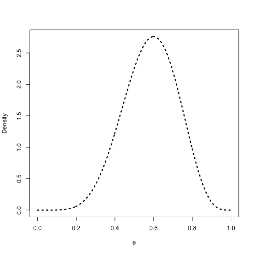

```r
plot(th, like, type='l', ylab = "Density", lty = 3, lwd = 3, xlab = expression(theta))
```

### Prior

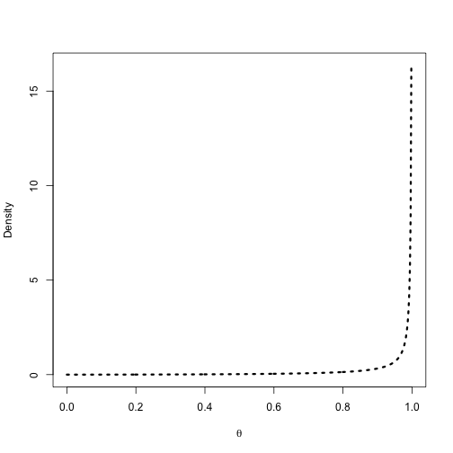

```r
plot(th, prior, type='l', ylab = "Density", lty = 3, lwd = 3, xlab = expression(theta))
```

### Posterior

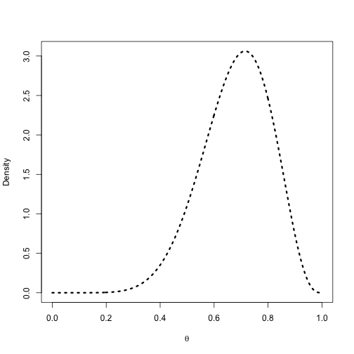

```r
plot(th, post, type='l', ylab = "Density", lty = 3, lwd = 3, xlab = expression(theta))
```

### Likelihood, Prior, and Posterior

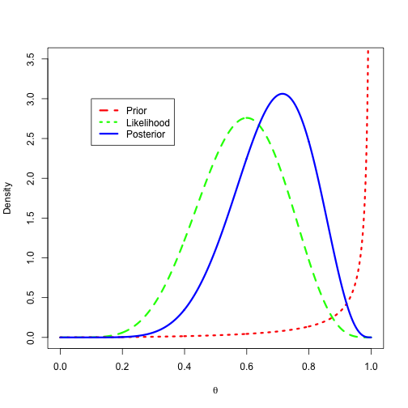

```r
plot(th, like, type = "l", ylab = "Density", xlab = expression(theta), lty = 2, lwd = 3,
     col = "green",ylim = c(0,3.5) )
lines(th, prior, lty = 3, lwd = 3, col= "red")
lines(th, post, lty=1, lwd = 3, col= "blue")
legend(0.1,3, c("Prior", "Likelihood", "Posterior"), lty=c(2,3,1), lwd=c(3,3,3),
       col = c("red", "green", "blue"))
```

### Cast of characters

- Observed data: \( x \)
- Note this could consist of many data points, e.g., \( x = x_{1:n}=(x_1,\dotsc,x_n) \).

### Marginal likelihood

The **marginal likelihood** is \[ p(x) = \int p(x|\theta) p(\theta) \,d\theta \]

- What is the marginal likelihood for the Bernoulli-Beta?

### Posterior predictive distribution

- We may wish to predict a new data point \( x_{n+1} \)
- We assume that \( x_{1:(n+1)} \) are independent given \( \theta \)

\[ \begin{aligned} p(x_{n+1}|x_{1:n}) &= \int p(x_{n+1},\theta|x_{1:n})\,d\theta\\ &= \int p(x_{n+1}|\theta,x_{1:n}) p(\theta|x_{1:n})\,d\theta\\ & = \int p(x_{n+1}|\theta) p(\theta|x_{1:n})\,d\theta. \end{aligned} \]

### Example: Back to the Beta-Bernoulli

Suppose \[ \; \theta\sim Beta(a,b) \] and \[ X_1,\dotsc,X_n\mid \theta \stackrel{iid}{\sim} Bernoulli(\theta) \]

Then the marginal likelihood is \[ \begin{aligned} &p(x_{1:n}) \\ &= \int p(x_{1:n}|\theta) p(\theta) \,d\theta\\ & = \int_0^1\theta^{\sum x_i}(1-\theta)^{n-\sum x_i}\frac{1}{B(a,b)}\theta^{a-1}(1-\theta)^{b-1} d\theta\\ & =\frac{B\big(a +\sum x_i,\, b + n-\sum x_i\big)}{B(a,b)}, \end{aligned} \] by the integral definition of the Beta function.

### Example continued

Let \( a_n = a +\sum x_i \) and \( b_n = b + n-\sum x_i. \)

It follows that the posterior distribution is \( p(\theta|x_{1:n}) = \Beta(\theta|a_n,b_n). \)

The posterior predictive can be derived to be \[ \begin{aligned} \Pr(X_{n+1} = 1\mid x_{1:n}) & = \int \Pr(X_{n+1} = 1\mid \theta) p(\theta|x_{1:n}) d\theta\\ & =\int \theta\,\Beta(\theta|a_n,b_n) =\frac{a_n}{a_n + b_n}, \end{aligned} \] hence, the posterior predictive p.m.f. is

\[ \begin{aligned} p(x_{n+1}|x_{1:n}) & = \frac{a_n^{x_{n+1}} b_n^{1-x_{n+1}}}{a_n + b_n}\I(x_{n+1}\in\{0,1\}). \end{aligned} \]